# Where to Find the Best Seafood and Cajun/Creole Food in New Orleans

- Show All Code
- Hide All Code
- View Source

A Yelp analysis of 565 restaurants and 224,050 reviews across 54 New Orleans neighborhoods

Published

November 14, 2026

## Research question

> **Where can someone find the best seafood and Cajun/Creole restaurants in New Orleans, and which neighborhood is best for finding them?**

## Executive summary

I used the Yelp Open Dataset to study 565 seafood and Cajun/Creole restaurants inside the New Orleans city limits and their 224,050 reviews. “Best” is measured with a reviewer-adjusted score: each review’s stars minus that reviewer’s usual rating. This rewards restaurants that make reviewers happier than they normally are, instead of restaurants that attract easy graders.

**Leonidas** (the Carrollton/Riverbend area Uptown) is the best neighborhood. It ranks first among the 10 neighborhoods with 10 or more of these restaurants, with or without the reviewer adjustment and at every reviewer threshold I tested. The French Quarter has the most choices (150 restaurants) and two of the top 10, but its typical restaurant is rated *below* what its reviewers usually give.

**The top restaurant is Avery’s On Tulane**, followed by Jaidyn’s Wing Stop/Food For The Soul and Tito’s Ceviche & Pisco.

## The answer: top 10 restaurants

A restaurant is ranked only if at least 20 of its reviews come from “eligible” reviewers: people who wrote 5 or more seafood/Cajun reviews, so their usual rating is known.

| Rank | Restaurant | Neighborhood | Yelp stars | Avg stars (all reviewers) | Reviews (all) | Reviews (eligible) | Adjusted score | Rank before adjustment |
| --- | --- | --- | --- | --- | --- | --- | --- | --- |
| 1 | Avery’s On Tulane | Tulane - Gravier | 4.5 | 4.64 | 306 | 87 | 0.61 | 4 |
| 2 | Jaidyn’s Wing Stop/Food For The Soul | Mid-City | 4.5 | 4.58 | 60 | 20 | 0.61 | 7 |
| 3 | Tito’s Ceviche & Pisco | Uptown | 4.5 | 4.72 | 221 | 86 | 0.59 | 3 |
| 4 | Restaurant August | Central Business District | 4.5 | 4.45 | 1,350 | 373 | 0.55 | 19 |
| 5 | Saint John | French Quarter | 4.0 | 4.26 | 42 | 20 | 0.55 | 53 |
| 6 | Cafe Fleur De Lis | French Quarter | 4.0 | 4.10 | 106 | 23 | 0.52 | 112 |
| 7 | Gabrielle Restaurant | Treme - Lafitte | 4.5 | 4.47 | 85 | 34 | 0.52 | 16 |
| 8 | Brigtsen’s Restaurant | Leonidas | 4.5 | 4.54 | 353 | 156 | 0.51 | 11 |
| 9 | Fiorella’s the Original | Gentilly Terrace | 4.5 | 4.44 | 133 | 61 | 0.49 | 22 |
| 10 | Restaurant Rebirth | Lower Garden District | 4.5 | 4.64 | 534 | 96 | 0.49 | 5 |

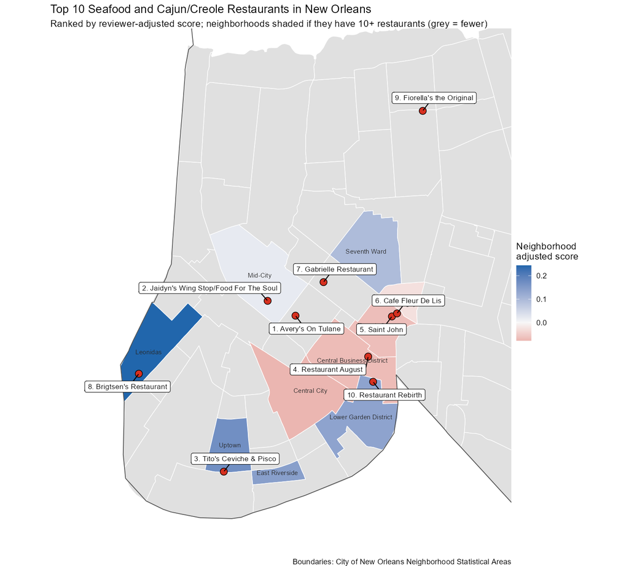

Final map: the top 10 restaurants on the Neighborhood Statistical Area boundaries

## Data and workflow

| File | What it does |
| --- | --- |
| R/import.R | Steps 1–2: streams the raw JSON, filters to New Orleans restaurants, saves RDS |
| R/categories.R | Step 3: category counts, co-occurrence, selection |
| R/reviews.R | Step 4: joins reviews to the selected restaurants |
| R/spatial.R | Step 5: spatial join with the Census city boundary |
| R/geography.R | Step 6: compares four geographic systems |
| R/analysis.R | Step 7: reviewer-adjusted scores, top 10, final map |

Packages: `tidyverse`, `jsonlite`, `lubridate`, `sf`, `tigris`, `scales`, `viridis`, plus `ggrepel` (map and chart labels) and `knitr` (tables).

Data sources:

- [Yelp Open Dataset](https://business.yelp.com/data/resources/open-dataset/): `yelp_academic_dataset_business.json` and `yelp_academic_dataset_review.json`
- [Census TIGER/Line](https://www.census.gov/geographies/mapping-files/time-series/geo/tiger-line-file.html) via [`tigris`](https://cran.r-project.org/package=tigris): 2024 places and tracts, 2020 ZCTAs
- City of New Orleans GIS: [Neighborhood Statistical Areas](https://maps.nola.gov/server/rest/services/Reference/Reference_Layers/MapServer/0) and [Wards](https://maps.nola.gov/server/rest/services/Administrative/Administrative_Layers/MapServer/3)

## Large-data management

I downloaded the JSON version of the dataset (4.35 GB) from the Yelp Open Dataset page after accepting Yelp’s terms. I skipped the separate 7.45 GB photo download because the project does not use photos. The download was far bigger than anything we used in class:

| Item | Size |
| --- | --- |
| Downloaded zip (`Yelp-JSON.zip`) | 4.35 GB |
| `yelp_academic_dataset_review.json` | 5.3 GB, 6,990,280 reviews |
| `yelp_academic_dataset_business.json` | 119 MB, 150,346 businesses |
| Final Louisiana restaurant reviews (`reviews_new_orleans.rds`) | 95 MB |
| Final seafood/Cajun reviews without text (`selected_reviews.rds`) | 7 MB |

Problems and how I handled them:

1. **The tar file would not open.** The zip held a `.tar` that Windows cannot open by double-clicking. My first `tar -xf` failed with “Archive is compressed”, so the file was actually gzip-compressed and needed `tar -xzf`.
2. **Disk space.** Unzipping everything would write the 4.35 GB tar plus 8.65 GB of JSON. Instead I streamed the tar straight out of the zip and extracted only the two files I needed (5.4 GB), skipping the user, check-in, and tip files.
3. **Memory.** Reading 7 million reviews into one data frame needs many gigabytes of RAM. `jsonlite::stream_in()` with a `handler` reads 100,000 lines at a time and keeps only reviews for Louisiana restaurants (558,340) before reading the next page, so the full file never sits in memory. The whole import took about 8 minutes.
4. **Only needed columns.** The business file kept 11 columns, and the analysis copy of the reviews drops the long `text` column.
5. **Compressed outputs.** Everything is saved as `xz`-compressed RDS. After saving, I deleted the 5.4 GB of extracted JSON.
6. **GitHub limits.** GitHub’s website rejects uploads over 25 MB, and git rejects files over 100 MB. The raw JSON and the 95 MB review file are in `.gitignore`. Everything this report needs (`selected_reviews.rds`, 7 MB) is in the repository.

## Steps 1–2: Import and filter to New Orleans

```r
library(tidyverse)
library(jsonlite)

business_file <- "data/raw/yelp_academic_dataset_business.json"
review_file   <- "data/raw/yelp_academic_dataset_review.json"
out_dir       <- "data/new_orleans"
dir.create(out_dir, recursive = TRUE, showWarnings = FALSE)

business_raw <- stream_in(file(business_file), verbose = FALSE)

business <- business_raw |>
  select(
    business_id, name, address, city, state, postal_code,
    latitude, longitude, stars, review_count, categories
  ) |>
  as_tibble()
rm(business_raw); invisible(gc())

cat("All businesses:", nrow(business), "\n")

la_restaurants <- business |>
  filter(
    state == "LA",
    !is.na(categories),
    str_detect(categories, regex("Restaurants", ignore_case = TRUE))
  ) |>
  mutate(
    postal_code   = na_if(postal_code, ""),
    categories    = str_squish(categories),
    business_name = str_squish(name),
    city_clean    = str_to_title(str_squish(city))
  ) |>
  distinct(business_id, .keep_all = TRUE)

new_orleans_restaurants <- la_restaurants |>
  filter(city_clean == "New Orleans")

cat("Louisiana restaurants:", nrow(la_restaurants), "\n")
cat("New Orleans restaurants:", nrow(new_orleans_restaurants), "\n")
la_restaurants |> count(city, sort = TRUE) |> print(n = 15)

new_orleans_restaurants |>
  summarise(
    number_of_restaurants = n(),
    missing_latitude   = sum(is.na(latitude)),
    missing_longitude  = sum(is.na(longitude)),
    missing_categories = sum(is.na(categories))
  ) |>
  print()

saveRDS(new_orleans_restaurants, file.path(out_dir, "business_new_orleans.rds"), compress = "xz")
saveRDS(la_restaurants,          file.path(out_dir, "business_la_restaurants.rds"), compress = "xz")

keep_ids <- la_restaurants$business_id
chunks   <- list()
n_read   <- 0

stream_in(
  file(review_file),
  handler = function(df) {
    n_read <<- n_read + nrow(df)
    kept <- df[df$business_id %in% keep_ids,
               c("review_id", "business_id", "user_id", "stars", "date",
                 "text", "useful", "funny", "cool")]
    chunks[[length(chunks) + 1]] <<- kept
    cat(sprintf("\rread %s reviews, kept %s",
                format(n_read, big.mark = ","),
                format(sum(map_int(chunks, nrow)), big.mark = ",")))
  },
  pagesize = 100000,
  verbose = FALSE
)
cat("\n")

reviews_la <- bind_rows(chunks) |> as_tibble()
rm(chunks); invisible(gc())

reviews_new_orleans <- reviews_la |>
  semi_join(new_orleans_restaurants, by = "business_id")

cat("Reviews read:", n_read, "\n")
cat("Reviews for LA restaurants:", nrow(reviews_la), "\n")
cat("Reviews for New Orleans restaurants:", nrow(reviews_new_orleans), "\n")

saveRDS(reviews_la, file.path(out_dir, "reviews_new_orleans.rds"), compress = "xz")

glimpse(readRDS(file.path(out_dir, "business_new_orleans.rds")))
cat("Saved files:\n")
print(file.info(list.files(out_dir, full.names = TRUE, pattern = "rds$"))["size"])
```

| Step | Count |
| --- | --- |
| All Yelp businesses | 150,346 |
| Louisiana restaurants | 3,640 |
| New Orleans restaurants | 2,261 |
| Reviews in the full file | 6,990,280 |
| Reviews for Louisiana restaurants | 558,340 |

A **New Orleans restaurant** has `state == "LA"`, the word “Restaurants” in its `categories`, and a Yelp `city` of New Orleans. The city label is cleaned first (capitalization and extra spaces), which recovered 2 restaurants an exact match would have missed. None of the 2,261 restaurants are missing coordinates or categories. In Step 5 this text label is checked against the official city boundary.

## Step 3: Choosing related categories

```r
library(tidyverse)

new_orleans_restaurants <- readRDS("data/new_orleans/business_new_orleans.rds")

restaurant_categories <- new_orleans_restaurants |>
  select(business_id, categories) |>
  separate_rows(categories, sep = ",") |>
  mutate(category = str_to_lower(str_squish(categories))) |>
  filter(category != "") |>
  distinct(business_id, category)

category_counts <- restaurant_categories |>
  filter(!category %in% c("restaurants", "food")) |>
  count(category, name = "number_of_restaurants", sort = TRUE)

print(category_counts, n = 25)

category_pairs <- restaurant_categories |>
  inner_join(restaurant_categories, by = "business_id", suffix = c("_1", "_2"),
             relationship = "many-to-many") |>
  filter(category_1 < category_2,
         !category_1 %in% c("restaurants", "food"),
         !category_2 %in% c("restaurants", "food")) |>
  count(category_1, category_2, name = "restaurants_with_both", sort = TRUE)

selected_categories <- c("seafood", "cajun/creole", "seafood markets")

category_pairs |>
  filter(category_1 %in% selected_categories | category_2 %in% selected_categories) |>
  print(n = 20)

category_pairs |>
  filter(category_1 %in% selected_categories, category_2 %in% selected_categories) |>
  print()

selected_flags <- restaurant_categories |>
  filter(category %in% selected_categories) |>
  mutate(value = TRUE) |>
  pivot_wider(names_from = category, values_from = value, values_fill = FALSE)

selected_restaurants <- new_orleans_restaurants |>
  inner_join(selected_flags, by = "business_id") |>
  mutate(categories_matched = `seafood` + `cajun/creole` + `seafood markets`)

selected_restaurants |>
  summarise(
    number_of_restaurants = n(),
    seafood = sum(`seafood`),
    cajun_creole = sum(`cajun/creole`),
    seafood_markets = sum(`seafood markets`),
    matched_two_or_more = sum(categories_matched >= 2),
    average_stars = mean(stars),
    total_reviews = sum(review_count)
  ) |>
  print()

zip_spread <- selected_restaurants |>
  count(postal_code, name = "number_of_restaurants", sort = TRUE)

print(zip_spread, n = 30)

zip_spread |>
  summarise(
    zip_codes = n(),
    zip_codes_with_10_or_more = sum(number_of_restaurants >= 10)
  ) |>
  print()

saveRDS(selected_restaurants, "data/new_orleans/selected_restaurants.rds", compress = "xz")
```

The most common categories among New Orleans restaurants:

| Category | Restaurants |
| --- | --- |
| nightlife | 541 |
| bars | 509 |
| cajun/creole | 402 |
| breakfast & brunch | 367 |
| sandwiches | 354 |
| seafood | 332 |
| american (new) | 324 |
| american (traditional) | 299 |
| coffee & tea | 208 |
| burgers | 202 |
| cafes | 173 |
| pizza | 172 |
| cocktail bars | 161 |
| event planning & services | 157 |
| southern | 155 |

I chose **Seafood**, **Cajun/Creole**, and **Seafood Markets**. They belong together because seafood is the core of Cajun and Creole cooking (gumbo, étouffée, po-boys, boiled crawfish), and seafood markets in New Orleans often serve ready-to-eat boiled seafood. Yelp has no separate “Cajun” or “Creole” tag, only the combined “Cajun/Creole”.

The co-occurrence counts support the grouping. Cajun/Creole and Seafood appear together more often than either appears with any other cuisine:

| Category 1 | Category 2 | Restaurants with both |
| --- | --- | --- |
| cajun/creole | seafood | 156 |
| cajun/creole | nightlife | 113 |
| bars | cajun/creole | 103 |
| nightlife | seafood | 89 |
| bars | seafood | 83 |
| breakfast & brunch | cajun/creole | 72 |
| cajun/creole | southern | 72 |
| american (new) | cajun/creole | 68 |
| american (traditional) | cajun/creole | 66 |
| american (traditional) | seafood | 53 |

| Category 1 | Category 2 | Restaurants with both |
| --- | --- | --- |
| cajun/creole | seafood | 156 |
| seafood | seafood markets | 21 |
| cajun/creole | seafood markets | 9 |

21 of the 22 seafood markets are also tagged Seafood, and the rest are tagged Cajun/Creole.

**Inclusion rule:** a restaurant is included if it has **at least one** of the three categories.

| Restaurants | Seafood | Cajun/Creole | Seafood Markets | Two or more categories | Average stars | Total reviews |
| --- | --- | --- | --- | --- | --- | --- |
| 578 | 332 | 402 | 22 | 170 | 3.8 | 220,858 |

The group spreads across the city: 12 ZIP codes and 10 neighborhoods each have at least 10 of these restaurants (Step 6), more than the required 7 areas.

## Step 4: Joining businesses to reviews

```r
library(tidyverse)

selected_restaurants <- readRDS("data/new_orleans/selected_restaurants.rds")
louisiana_reviews <- readRDS("data/new_orleans/reviews_new_orleans.rds")

category_reviews <- louisiana_reviews |>
  semi_join(selected_restaurants, by = "business_id") |>
  select(-text) |>
  mutate(
    review_date = as_date(ymd_hms(date)),
    review_year = year(review_date)
  ) |>
  select(-date)

category_reviews |>
  summarise(
    reviews = n(),
    reviewers = n_distinct(user_id),
    restaurants_with_reviews = n_distinct(business_id),
    first_review = min(review_date),
    last_review = max(review_date),
    average_stars = mean(stars)
  ) |>
  print()

selected_restaurants |>
  left_join(count(category_reviews, business_id, name = "reviews_in_file"), by = "business_id") |>
  summarise(
    yelp_review_count = sum(review_count),
    reviews_in_file = sum(reviews_in_file, na.rm = TRUE)
  ) |>
  print()

saveRDS(category_reviews, "data/new_orleans/selected_reviews.rds", compress = "xz")
```

Reviews were filtered to the selected restaurants with `semi_join()` before any further work, so reviews for thousands of unrelated businesses are not carried through the analysis. The tables are linked by `business_id` (one restaurant to many reviews).

| Reviews | Reviewers | Restaurants with reviews | First review | Last review | Average stars |
| --- | --- | --- | --- | --- | --- |
| 225,209 | 129,408 | 578 | 2005-03-14 | 2022-01-19 | 3.92 |

The review file has slightly more reviews (225,209) than the sum of Yelp’s `review_count` field (220,858). The two fields were probably updated at slightly different times.

## Step 5: Spatial join with the official city boundary

```r
library(tidyverse)
library(sf)
library(tigris)

options(tigris_use_cache = TRUE)
dir.create("figures", showWarnings = FALSE)

la_restaurants <- readRDS("data/new_orleans/business_la_restaurants.rds")
selected_restaurants <- readRDS("data/new_orleans/selected_restaurants.rds")

louisiana_places <- places(state = "LA", cb = TRUE, year = 2024, class = "sf", progress_bar = FALSE) |>
  st_transform(4326)

new_orleans_boundary <- louisiana_places |>
  filter(NAME == "New Orleans")

restaurant_points <- la_restaurants |>
  filter(!is.na(longitude), !is.na(latitude)) |>
  st_as_sf(coords = c("longitude", "latitude"), crs = 4326, remove = FALSE)

restaurants_with_place <- restaurant_points |>
  st_join(louisiana_places |> select(GEOID, place_name = NAME), join = st_within, left = TRUE) |>
  mutate(place_name = replace_na(place_name, "Outside any Census place"))

restaurants_with_place |>
  st_drop_geometry() |>
  count(city_clean, place_name, sort = TRUE) |>
  print(n = 25)

city_check <- restaurants_with_place |>
  st_drop_geometry() |>
  mutate(
    yelp_says_new_orleans = city_clean == "New Orleans",
    census_says_new_orleans = place_name == "New Orleans"
  ) |>
  count(yelp_says_new_orleans, census_says_new_orleans)

print(city_check)

restaurants_with_place |>
  st_drop_geometry() |>
  filter(city_clean == "New Orleans", place_name != "New Orleans") |>
  select(business_name, address, postal_code, place_name, latitude, longitude) |>
  print(n = Inf)

selected_check <- restaurants_with_place |>
  st_drop_geometry() |>
  semi_join(selected_restaurants, by = "business_id") |>
  count(inside_official_boundary = place_name == "New Orleans")

print(selected_check)

new_orleans_map_data <- restaurants_with_place |>
  filter(place_name == "New Orleans") |>
  semi_join(st_drop_geometry(selected_restaurants), by = "business_id")

step5_map <- ggplot() +
  geom_sf(data = new_orleans_boundary, fill = "grey95", color = "grey35") +
  geom_sf(data = new_orleans_map_data, aes(color = stars), alpha = 0.7, size = 1.4) +
  scale_color_viridis_c(option = "C", limits = c(1, 5)) +
  coord_sf(xlim = c(-90.15, -89.90), ylim = c(29.88, 30.08)) +
  labs(
    title = "Seafood and Cajun/Creole Restaurants Inside the New Orleans City Boundary",
    subtitle = "Census TIGER/Line 2024 place boundary",
    color = "Business\nstars"
  ) +
  theme_minimal()

ggsave("figures/step5_city_boundary_map.png", step5_map, width = 9, height = 7, dpi = 150, bg = "white")
```

The Yelp `city` field is a mailing label. The Census TIGER/Line place boundary is the legal city limit. Comparing them for all 3,640 Louisiana restaurants:

| Yelp says New Orleans | Inside Census New Orleans boundary | Restaurants |
| --- | --- | --- |
| FALSE | FALSE | 1,375 |
| FALSE | TRUE | 4 |
| TRUE | FALSE | 57 |
| TRUE | TRUE | 2,204 |

The 57 mismatches with a Yelp city of New Orleans are not errors to delete. Most are in ZIP codes 70121 and 70123, where the post office uses “New Orleans” even though the area is in Jefferson Parish (Elmwood, Harahan, Jefferson, River Ridge):

| Census place | ZIP code | Restaurants |
| --- | --- | --- |
| Elmwood | 70123 | 14 |
| Jefferson | 70121 | 13 |
| Harahan | 70123 | 10 |
| Elmwood | 70121 | 4 |
| Terrytown | 70056 | 4 |
| River Ridge | 70123 | 3 |
| Arabi | 70032 | 2 |
| Harvey | 70058 | 2 |

For the seafood and Cajun/Creole group, **565 of 578 restaurants are inside the city boundary**. I used the stricter boundary-based definition from here on, so every restaurant can be assigned to a city neighborhood.

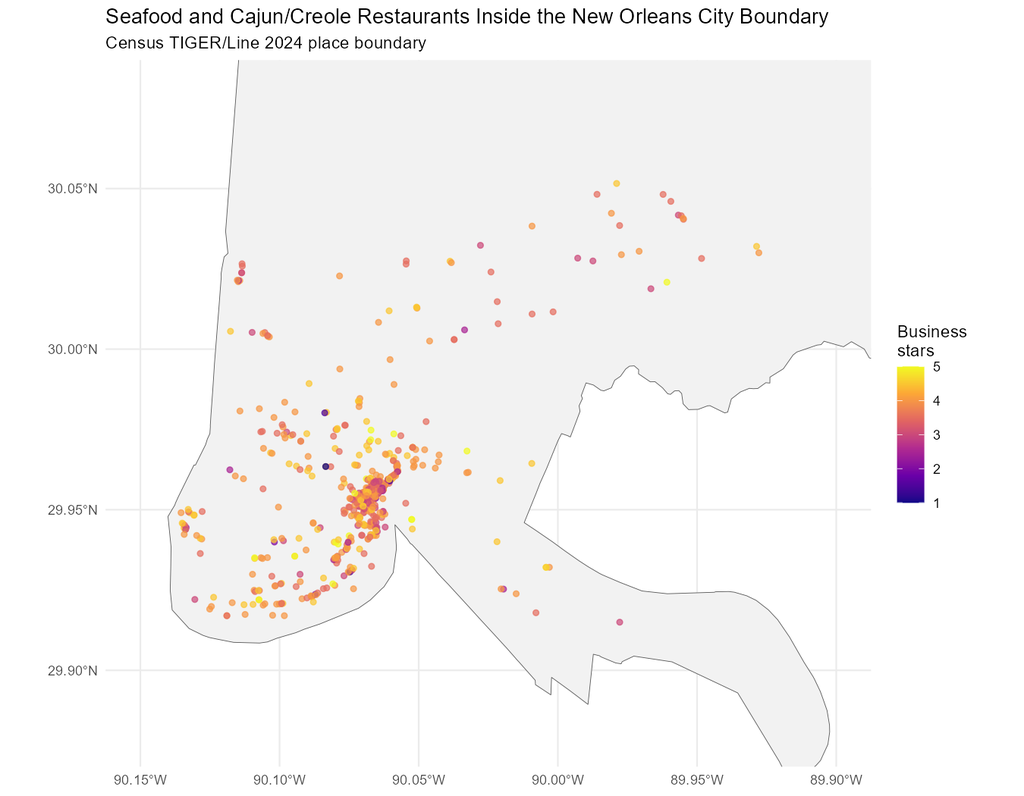

Selected restaurants inside the New Orleans city boundary

## Step 6: Choosing a geographic system

```r
library(tidyverse)
library(sf)
library(tigris)
library(viridis)

options(tigris_use_cache = TRUE)
suppressMessages(sf_use_s2(FALSE))
dir.create("figures", showWarnings = FALSE)

selected_restaurants <- readRDS("data/new_orleans/selected_restaurants.rds")
category_reviews <- readRDS("data/new_orleans/selected_reviews.rds")

new_orleans_boundary <- places(state = "LA", cb = TRUE, year = 2024, progress_bar = FALSE) |>
  filter(NAME == "New Orleans") |>
  st_transform(4326)

restaurant_points <- selected_restaurants |>
  st_as_sf(coords = c("longitude", "latitude"), crs = 4326, remove = FALSE) |>
  st_filter(new_orleans_boundary, .predicate = st_within)

nola_url <- "https://maps.nola.gov/server/rest/services"
query <- "query?where=1%3D1&outFields=*&outSR=4326&f=geojson"

zcta_boundaries <- zctas(cb = FALSE, year = 2020, starts_with = c("700", "701"), progress_bar = FALSE) |>
  st_transform(4326) |>
  st_filter(new_orleans_boundary, .predicate = st_intersects) |>
  transmute(area_name = ZCTA5CE20)

zcta_projected <- st_transform(zcta_boundaries, 26915)
overlap <- as.numeric(st_area(st_intersection(zcta_projected, st_transform(st_geometry(new_orleans_boundary), 26915)))) /
  as.numeric(st_area(zcta_projected))
zcta_boundaries <- zcta_boundaries[overlap > 0.25, ]

tract_boundaries <- tracts(state = "LA", county = "Orleans", cb = TRUE, year = 2024, progress_bar = FALSE) |>
  st_transform(4326) |>
  transmute(area_name = NAMELSAD)

nsa_boundaries <- st_read(file.path(nola_url, "Reference/Reference_Layers/MapServer/0", query), quiet = TRUE) |>
  transmute(area_name = str_to_title(GNOCDC_LAB))

ward_boundaries <- st_read(file.path(nola_url, "Administrative/Administrative_Layers/MapServer/3", query), quiet = TRUE) |>
  transmute(area_name = paste("Ward", WARD))

geographies <- list(
  "ZIP/ZCTA" = zcta_boundaries,
  "Census tract" = tract_boundaries,
  "Neighborhood Statistical Area" = nsa_boundaries,
  "Ward" = ward_boundaries
)

reviewer_baselines <- category_reviews |>
  group_by(user_id) |>
  summarise(reviewer_mean = mean(stars), reviewer_review_count = n(), .groups = "drop")

eligible_reviews <- category_reviews |>
  inner_join(reviewer_baselines, by = "user_id") |>
  filter(reviewer_review_count >= 5) |>
  mutate(normalized_score = stars - reviewer_mean)

assign_areas <- function(boundaries) {
  restaurant_points |>
    st_join(boundaries, join = st_within, left = TRUE) |>
    st_drop_geometry() |>
    distinct(business_id, .keep_all = TRUE)
}

summarise_areas <- function(assigned) {
  normalized_by_area <- eligible_reviews |>
    inner_join(select(assigned, business_id, area_name), by = "business_id") |>
    group_by(area_name) |>
    summarise(
      eligible_reviews = n(),
      average_normalized_score = mean(normalized_score),
      .groups = "drop"
    )

  assigned |>
    filter(!is.na(area_name)) |>
    group_by(area_name) |>
    summarise(
      number_of_restaurants = n(),
      average_business_stars = mean(stars),
      median_business_stars = median(stars),
      total_reviews = sum(review_count),
      .groups = "drop"
    ) |>
    left_join(normalized_by_area, by = "area_name") |>
    arrange(desc(number_of_restaurants))
}

assigned_by_system <- map(geographies, assign_areas)
summary_by_system <- map(assigned_by_system, summarise_areas)

comparison_table <- imap_dfr(summary_by_system, function(area_summary, system) {
  tibble(
    geographic_system = system,
    number_of_areas = nrow(geographies[[system]]),
    areas_with_restaurants = nrow(area_summary),
    areas_with_10_or_more = sum(area_summary$number_of_restaurants >= 10),
    areas_with_under_5 = sum(area_summary$number_of_restaurants < 5),
    restaurants_assigned = sum(!is.na(assigned_by_system[[system]]$area_name)),
    unmatched_restaurants = sum(is.na(assigned_by_system[[system]]$area_name)),
    smallest_area_count = min(area_summary$number_of_restaurants),
    largest_area_count = max(area_summary$number_of_restaurants),
    median_area_count = median(area_summary$number_of_restaurants)
  )
})

print(comparison_table, width = Inf)

iwalk(summary_by_system, function(area_summary, system) {
  cat("\n", system, "\n")
  area_summary |>
    filter(number_of_restaurants >= 10) |>
    arrange(desc(average_normalized_score)) |>
    mutate(across(where(is.double), \(x) round(x, 2))) |>
    print(n = 15, width = Inf)
})

map_system <- function(system, file_name) {
  map_data <- geographies[[system]] |>
    left_join(summary_by_system[[system]], by = "area_name") |>
    mutate(number_of_restaurants = replace_na(number_of_restaurants, 0L)) |>
    st_intersection(st_geometry(new_orleans_boundary))

  area_map <- ggplot() +
    geom_sf(data = map_data, aes(fill = number_of_restaurants), color = "white", linewidth = 0.2) +
    geom_sf(data = restaurant_points, color = "black", size = 0.5, alpha = 0.5) +
    scale_fill_viridis_c(option = "D", trans = "sqrt", name = "Restaurants") +
    coord_sf(xlim = c(-90.14, -89.92), ylim = c(29.89, 30.07)) +
    labs(
      title = paste("Seafood and Cajun/Creole Restaurants by", system),
      subtitle = paste(nrow(geographies[[system]]), "areas; black dots are restaurants")
    ) +
    theme_void() +
    theme(plot.background = element_rect(fill = "white", color = NA))

  ggsave(file.path("figures", file_name), area_map, width = 8, height = 7, dpi = 150, bg = "white")
}

map_system("ZIP/ZCTA", "map_zcta.png")
map_system("Census tract", "map_tract.png")
map_system("Neighborhood Statistical Area", "map_neighborhood.png")
map_system("Ward", "map_ward.png")

size_plot <- imap_dfr(summary_by_system, \(area_summary, system) mutate(area_summary, geographic_system = system)) |>
  mutate(geographic_system = fct_reorder(geographic_system, number_of_restaurants, median)) |>
  ggplot(aes(x = number_of_restaurants, y = geographic_system)) +
  geom_vline(xintercept = 10, linetype = "dashed", color = "grey50") +
  geom_jitter(height = 0.15, width = 0, alpha = 0.6, color = "#2c7fb8") +
  geom_boxplot(fill = NA, outlier.shape = NA, width = 0.5) +
  scale_x_log10() +
  labs(
    title = "How Many Restaurants Fall in Each Area?",
    subtitle = "Each dot is one area that has at least one restaurant; dashed line marks 10 restaurants",
    x = "Restaurants per area (log scale)",
    y = NULL
  ) +
  theme_minimal()

ggsave("figures/area_size_comparison.png", size_plot, width = 9, height = 5, dpi = 150, bg = "white")

neighborhood_rank_plot <- summary_by_system[["Neighborhood Statistical Area"]] |>
  filter(number_of_restaurants >= 10) |>
  mutate(area_name = fct_reorder(area_name, average_normalized_score)) |>
  ggplot(aes(x = average_normalized_score, y = area_name)) +
  geom_vline(xintercept = 0, color = "grey60") +
  geom_point(aes(size = number_of_restaurants, color = average_business_stars)) +
  scale_color_viridis_c(option = "C", name = "Avg business\nstars") +
  scale_size_continuous(name = "Restaurants") +
  labs(
    title = "Neighborhoods with 10+ Seafood and Cajun/Creole Restaurants",
    subtitle = "Normalized score = stars minus the reviewer's usual rating (reviewers with 5+ reviews)",
    x = "Average reviewer-adjusted score",
    y = NULL
  ) +
  theme_minimal()

ggsave("figures/neighborhood_ranking.png", neighborhood_rank_plot, width = 9, height = 6, dpi = 150, bg = "white")

saveRDS(assigned_by_system[["Neighborhood Statistical Area"]], "data/new_orleans/selected_restaurants_neighborhoods.rds", compress = "xz")
```

I compared four systems by spatially joining the 565 restaurants to each:

| Geographic system | Number of areas | Areas with restaurants | Areas with 10+ | Areas with under 5 | Restaurants assigned | Unmatched | Smallest area count | Largest area count | Median area count |
| --- | --- | --- | --- | --- | --- | --- | --- | --- | --- |
| ZIP/ZCTA | 20 | 17 | 12 | 1 | 565 | 0 | 2 | 194 | 15 |
| Census tract | 184 | 105 | 9 | 81 | 565 | 0 | 1 | 98 | 2 |
| Neighborhood Statistical Area | 72 | 54 | 10 | 29 | 565 | 0 | 1 | 150 | 4 |
| Ward | 17 | 17 | 15 | 0 | 563 | 2 | 5 | 109 | 21 |

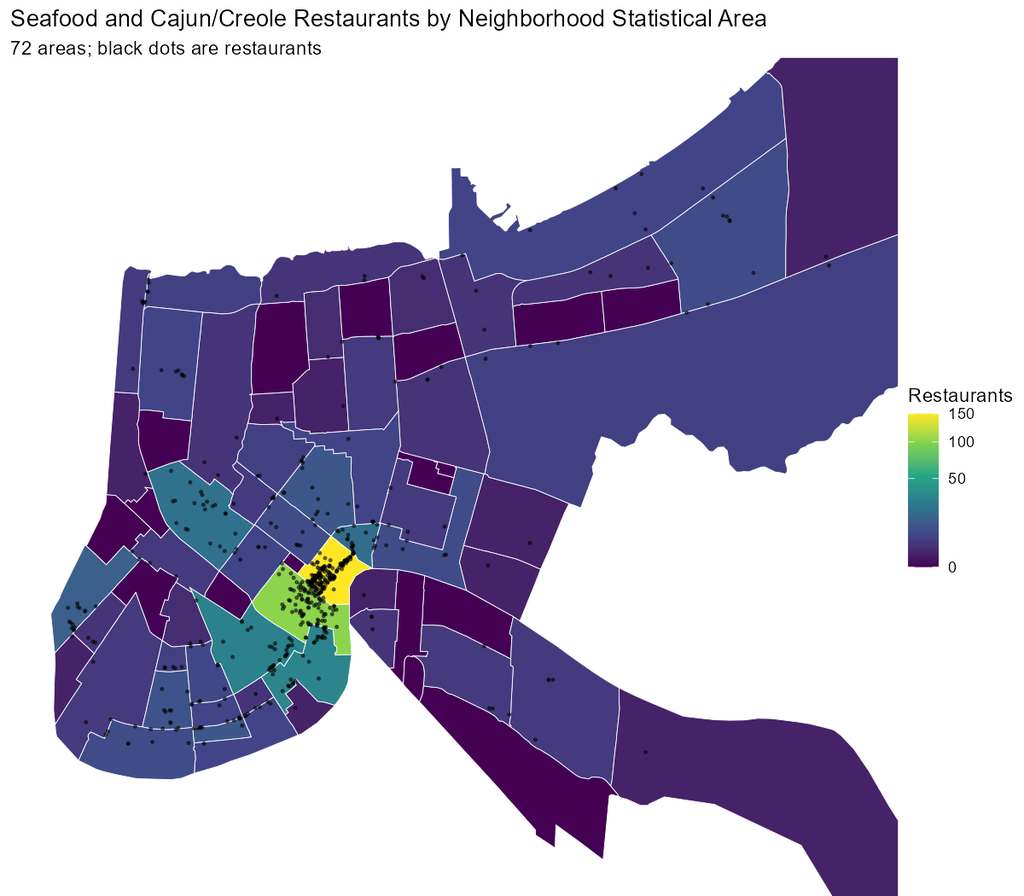

Neighborhood Statistical Areas

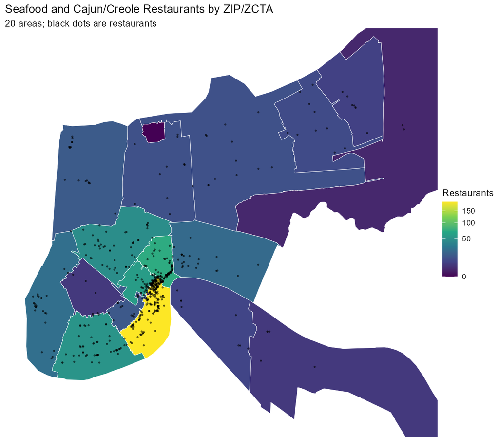

ZIP codes (ZCTAs)

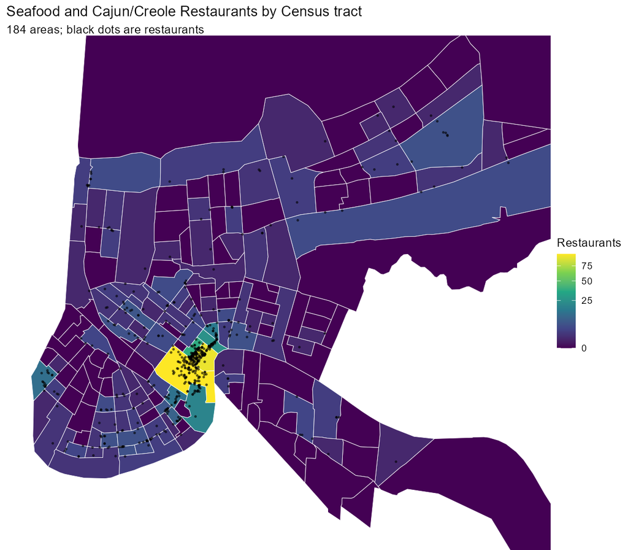

Census tracts

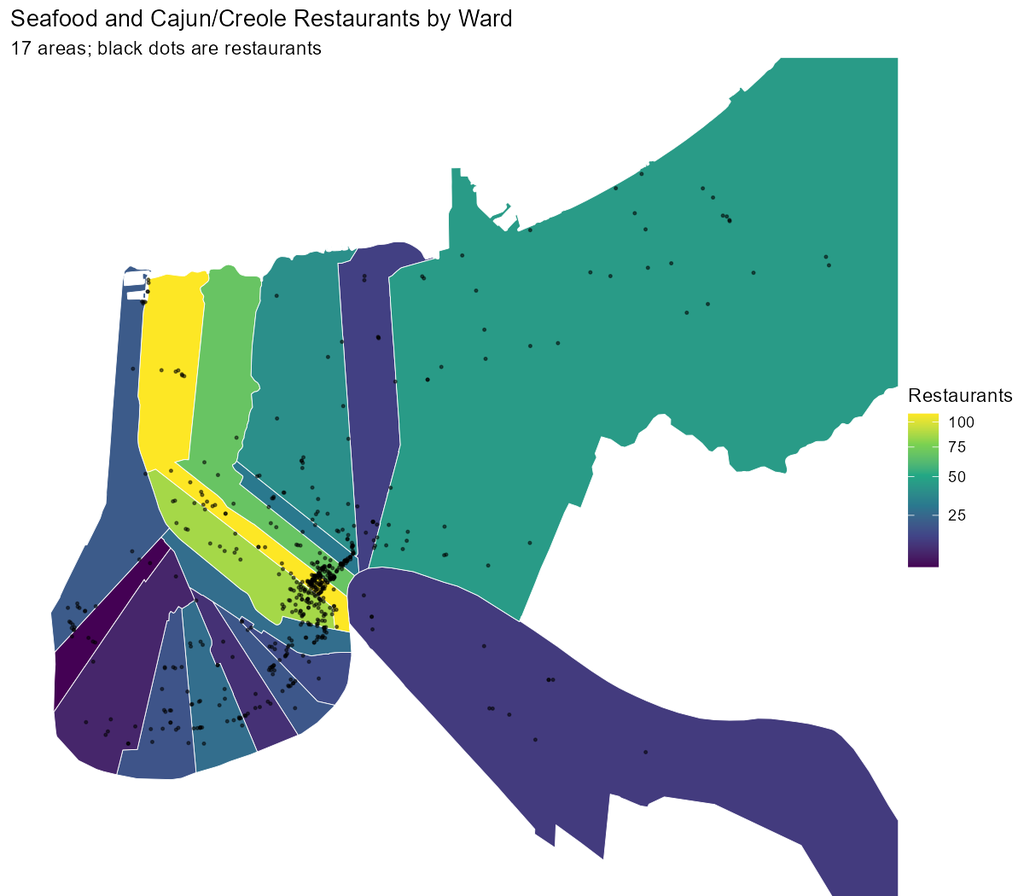

Wards

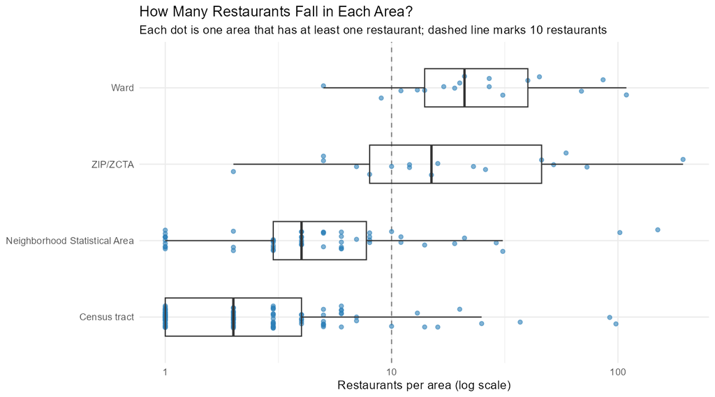

Restaurants per area under each system

**I selected Neighborhood Statistical Areas.**

- **They match the question.** Visitors choose where to eat by neighborhood (French Quarter, Marigny, Uptown), not by ZIP code, tract number, or ward.
- **There are enough restaurants to compare.** 10 neighborhoods have 10+ restaurants, and every restaurant is assigned to one.
- **They are not too big.** ZIP 70130 holds 194 restaurants, a third of the total, and mixes the French Quarter, the Central Business District, and the Warehouse District. Neighborhoods separate them.
- **They are documented.** The City of New Orleans built them from census tracts for planning.

The other systems: **census tracts** are too small (median of 2 restaurants, 81 tracts under 5). **Wards** have the most stable counts (every ward has 5+), but the names are historical numbers that mean little to a general audience, and 2 restaurants on the city edge fell outside every ward. **ZIP codes** are a reasonable second choice and were used as a check.

What neighborhoods hide: 29 neighborhoods have fewer than 5 restaurants, so their averages are unreliable. **Only neighborhoods with 10 or more restaurants are ranked.**

| Neighborhood | Restaurants | Avg business stars | Total reviews | Eligible reviews | Avg adjusted score |
| --- | --- | --- | --- | --- | --- |
| Leonidas | 14 | 4.00 | 4,367 | 1,356 | 0.24 |
| Uptown | 10 | 4.10 | 1,891 | 712 | 0.17 |
| East Riverside | 11 | 3.82 | 5,957 | 1,686 | 0.14 |
| Lower Garden District | 31 | 3.73 | 13,301 | 3,093 | 0.14 |
| Seventh Ward | 11 | 4.32 | 1,505 | 356 | 0.09 |
| Mid-City | 21 | 3.86 | 6,596 | 2,052 | 0.02 |
| Marigny | 19 | 3.97 | 5,952 | 1,293 | -0.03 |
| French Quarter | 150 | 3.64 | 89,823 | 15,984 | -0.07 |
| Central Business District | 102 | 3.72 | 55,534 | 11,081 | -0.07 |
| Central City | 29 | 3.95 | 6,118 | 1,567 | -0.08 |

## Step 7: All reviewers vs. selected reviewers

```r
library(tidyverse)
library(sf)
library(tigris)
library(ggrepel)

options(tigris_use_cache = TRUE)
suppressMessages(sf_use_s2(FALSE))
dir.create("figures", showWarnings = FALSE)
dir.create("output", showWarnings = FALSE)

city_restaurants <- readRDS("data/new_orleans/selected_restaurants_neighborhoods.rds")

category_reviews <- readRDS("data/new_orleans/selected_reviews.rds") |>
  semi_join(city_restaurants, by = "business_id")

minimum_reviewer_reviews <- 5
minimum_eligible_reviews <- 20
minimum_neighborhood_restaurants <- 10

all_reviewer_summary <- category_reviews |>
  group_by(business_id) |>
  summarise(
    number_of_reviews_all_reviewers = n(),
    average_stars_all_reviewers = mean(stars),
    median_stars_all_reviewers = median(stars),
    .groups = "drop"
  )

reviewer_baselines <- category_reviews |>
  group_by(user_id) |>
  summarise(
    reviewer_mean = mean(stars),
    reviewer_median = median(stars),
    reviewer_review_count = n(),
    .groups = "drop"
  )

category_reviews_adjusted <- category_reviews |>
  left_join(reviewer_baselines, by = "user_id") |>
  mutate(
    normalized_mean_score = stars - reviewer_mean,
    normalized_median_score = stars - reviewer_median
  ) |>
  left_join(select(city_restaurants, business_id, business_name, area_name), by = "business_id")

score_restaurants <- function(adjusted_reviews) {
  adjusted_reviews |>
    group_by(business_id) |>
    summarise(
      number_of_reviews_eligible_reviewers = n(),
      average_stars_eligible_reviewers = mean(stars),
      average_normalized_score = mean(normalized_mean_score),
      median_normalized_score = median(normalized_mean_score),
      .groups = "drop"
    )
}

score_neighborhoods <- function(adjusted_reviews) {
  adjusted_reviews |>
    group_by(area_name) |>
    summarise(average_normalized_score = mean(normalized_mean_score), .groups = "drop")
}

ranked_neighborhoods <- city_restaurants |>
  count(area_name, name = "number_of_restaurants") |>
  filter(number_of_restaurants >= minimum_neighborhood_restaurants) |>
  pull(area_name)

threshold_table <- map_dfr(c(2, 3, 5, 10), function(threshold) {
  eligible_ids <- reviewer_baselines |> filter(reviewer_review_count >= threshold)
  eligible <- category_reviews_adjusted |> semi_join(eligible_ids, by = "user_id")
  neighborhood_scores <- eligible |>
    filter(area_name %in% ranked_neighborhoods) |>
    score_neighborhoods() |>
    arrange(desc(average_normalized_score))
  restaurant_scores <- score_restaurants(eligible) |>
    filter(number_of_reviews_eligible_reviewers >= minimum_eligible_reviews)

  tibble(
    minimum_reviews_per_reviewer = threshold,
    reviewers_retained = nrow(eligible_ids),
    percent_of_reviewers = 100 * nrow(eligible_ids) / nrow(reviewer_baselines),
    percent_of_reviews = 100 * nrow(eligible) / nrow(category_reviews),
    restaurants_with_20_eligible_reviews = nrow(restaurant_scores),
    top_neighborhood = neighborhood_scores$area_name[1],
    second_neighborhood = neighborhood_scores$area_name[2],
    third_neighborhood = neighborhood_scores$area_name[3]
  )
})

eligible_reviewers <- reviewer_baselines |>
  filter(reviewer_review_count >= minimum_reviewer_reviews)

eligible_adjusted_reviews <- category_reviews_adjusted |>
  semi_join(eligible_reviewers, by = "user_id")

baseline_comparison <- eligible_adjusted_reviews |>
  summarise(
    reviews = n(),
    percent_mean_score_exactly_zero = 100 * mean(normalized_mean_score == 0),
    percent_median_score_exactly_zero = 100 * mean(normalized_median_score == 0),
    correlation_mean_vs_median = cor(normalized_mean_score, normalized_median_score)
  )

restaurant_summary <- city_restaurants |>
  select(business_id, business_name, address, area_name, latitude, longitude, stars, review_count) |>
  left_join(all_reviewer_summary, by = "business_id") |>
  left_join(score_restaurants(eligible_adjusted_reviews), by = "business_id") |>
  mutate(
    raw_rank = min_rank(desc(if_else(number_of_reviews_eligible_reviewers >= minimum_eligible_reviews,
                                     average_stars_all_reviewers, NA_real_))),
    adjusted_rank = min_rank(desc(if_else(number_of_reviews_eligible_reviewers >= minimum_eligible_reviews,
                                          average_normalized_score, NA_real_)))
  ) |>
  arrange(adjusted_rank)

top_10_restaurants <- restaurant_summary |>
  filter(adjusted_rank <= 10) |>
  arrange(adjusted_rank) |>
  mutate(rank = row_number())

raw_top_10 <- restaurant_summary |>
  filter(raw_rank <= 10) |>
  arrange(raw_rank)

biggest_rank_changes <- restaurant_summary |>
  filter(!is.na(adjusted_rank)) |>
  mutate(rank_change = raw_rank - adjusted_rank) |>
  arrange(desc(abs(rank_change))) |>
  slice_head(n = 10)

restaurant_level <- restaurant_summary |>
  filter(number_of_reviews_eligible_reviewers >= minimum_eligible_reviews)

neighborhood_summary <- restaurant_level |>
  group_by(area_name) |>
  summarise(qualifying_restaurants = n(), .groups = "drop") |>
  right_join(
    city_restaurants |>
      count(area_name, name = "number_of_restaurants") |>
      filter(number_of_restaurants >= minimum_neighborhood_restaurants),
    by = "area_name"
  ) |>
  left_join(
    category_reviews_adjusted |>
      group_by(area_name) |>
      summarise(reviews_all_reviewers = n(), average_stars_all_reviewers = mean(stars), .groups = "drop"),
    by = "area_name"
  ) |>
  left_join(
    eligible_adjusted_reviews |>
      group_by(area_name) |>
      summarise(eligible_reviews = n(), average_normalized_score = mean(normalized_mean_score), .groups = "drop"),
    by = "area_name"
  ) |>
  left_join(count(top_10_restaurants, area_name, name = "top_10_restaurants"), by = "area_name") |>
  left_join(
    restaurant_level |>
      filter(average_normalized_score > 0) |>
      count(area_name, name = "above_average_restaurants"),
    by = "area_name"
  ) |>
  mutate(
    across(c(qualifying_restaurants, top_10_restaurants, above_average_restaurants), \(x) replace_na(x, 0L)),
    raw_rank = min_rank(desc(average_stars_all_reviewers)),
    adjusted_rank = min_rank(desc(average_normalized_score))
  ) |>
  select(area_name, number_of_restaurants, qualifying_restaurants, above_average_restaurants,
         top_10_restaurants, reviews_all_reviewers, average_stars_all_reviewers, raw_rank,
         eligible_reviews, average_normalized_score, adjusted_rank) |>
  arrange(adjusted_rank)

saveRDS(
  list(
    threshold_table = threshold_table,
    baseline_comparison = baseline_comparison,
    restaurant_summary = restaurant_summary,
    top_10_restaurants = top_10_restaurants,
    raw_top_10 = raw_top_10,
    biggest_rank_changes = biggest_rank_changes,
    neighborhood_summary = neighborhood_summary
  ),
  "output/analysis_results.rds"
)

raw_vs_adjusted_plot <- restaurant_level |>
  ggplot(aes(x = average_stars_all_reviewers, y = average_normalized_score)) +
  geom_hline(yintercept = 0, color = "grey70") +
  geom_point(aes(size = number_of_reviews_all_reviewers), alpha = 0.45, color = "#2c7fb8") +
  geom_point(data = top_10_restaurants, color = "#d7301f", size = 2.5) +
  geom_text_repel(data = top_10_restaurants, aes(label = business_name), size = 3, seed = 1) +
  labs(
    title = "Raw Restaurant Ratings Compared with Reviewer-Adjusted Scores",
    subtitle = paste0("Restaurants with ", minimum_eligible_reviews,
                      "+ reviews from reviewers with ", minimum_reviewer_reviews,
                      "+ reviews; top 10 in red"),
    x = "Average stars from all reviewers",
    y = "Average normalized score",
    size = "Reviews"
  ) +
  theme_minimal()

ggsave("figures/raw_vs_adjusted.png", raw_vs_adjusted_plot, width = 9, height = 6, dpi = 150, bg = "white")

rank_change_plot <- neighborhood_summary |>
  mutate(area_name = fct_reorder(area_name, -adjusted_rank)) |>
  pivot_longer(c(raw_rank, adjusted_rank), names_to = "ranking", values_to = "rank") |>
  mutate(ranking = recode(ranking, raw_rank = "All reviewers (average stars)",
                          adjusted_rank = "Reviewer-adjusted score")) |>
  ggplot(aes(x = rank, y = area_name)) +
  geom_line(aes(group = area_name), color = "grey70") +
  geom_point(aes(color = ranking), size = 3) +
  scale_x_reverse(breaks = 1:10) +
  scale_color_manual(values = c("#9ecae1", "#08519c")) +
  labs(
    title = "Neighborhood Rankings Before and After Reviewer Adjustment",
    subtitle = paste0("Neighborhoods with ", minimum_neighborhood_restaurants, "+ seafood and Cajun/Creole restaurants"),
    x = "Rank (1 = best)",
    y = NULL,
    color = NULL
  ) +
  theme_minimal() +
  theme(legend.position = "top")

ggsave("figures/neighborhood_rank_change.png", rank_change_plot, width = 9, height = 5.5, dpi = 150, bg = "white")

new_orleans_boundary <- places(state = "LA", cb = TRUE, year = 2024, progress_bar = FALSE) |>
  filter(NAME == "New Orleans") |>
  st_transform(4326)

nsa_boundaries <- st_read(
  "https://maps.nola.gov/server/rest/services/Reference/Reference_Layers/MapServer/0/query?where=1%3D1&outFields=*&outSR=4326&f=geojson",
  quiet = TRUE
) |>
  transmute(area_name = str_to_title(GNOCDC_LAB)) |>
  left_join(select(neighborhood_summary, area_name, average_normalized_score), by = "area_name")

top_10_points <- top_10_restaurants |>
  st_as_sf(coords = c("longitude", "latitude"), crs = 4326, remove = FALSE)

map_box <- st_bbox(top_10_points)

final_map <- ggplot() +
  geom_sf(data = nsa_boundaries, aes(fill = average_normalized_score), color = "white", linewidth = 0.3) +
  geom_sf(data = new_orleans_boundary, fill = NA, color = "grey30", linewidth = 0.4) +
  geom_sf_text(
    data = filter(nsa_boundaries, !is.na(average_normalized_score)),
    aes(label = area_name), size = 2.6, color = "grey15", fun.geometry = st_point_on_surface
  ) +
  geom_sf(data = top_10_points, color = "black", fill = "#d7301f", shape = 21, size = 3.5) +
  geom_label_repel(
    data = top_10_points,
    aes(x = longitude, y = latitude, label = paste0(rank, ". ", business_name)),
    size = 3, seed = 2, min.segment.length = 0, box.padding = 0.5
  ) +
  scale_fill_gradient2(
    low = "#b2182b", mid = "#f7f7f7", high = "#2166ac", midpoint = 0,
    na.value = "grey88", name = "Neighborhood\nadjusted score"
  ) +
  coord_sf(
    xlim = c(map_box[["xmin"]] - 0.02, map_box[["xmax"]] + 0.02),
    ylim = c(map_box[["ymin"]] - 0.015, map_box[["ymax"]] + 0.015)
  ) +
  labs(
    title = "Top 10 Seafood and Cajun/Creole Restaurants in New Orleans",
    subtitle = paste0("Ranked by reviewer-adjusted score; neighborhoods shaded if they have ",
                      minimum_neighborhood_restaurants, "+ restaurants (grey = fewer)"),
    caption = "Boundaries: City of New Orleans Neighborhood Statistical Areas"
  ) +
  theme_void() +
  theme(plot.background = element_rect(fill = "white", color = NA))

ggsave("figures/final_top10_map.png", final_map, width = 10, height = 9, dpi = 150, bg = "white")
```

### Choosing reviewers

A reviewer’s usual rating can only be estimated if they wrote several reviews in this category. Most people wrote just one:

| Min reviews per reviewer | Reviewers retained | % of reviewers | % of reviews | Restaurants with 20+ eligible reviews | #1 neighborhood | #2 | #3 |
| --- | --- | --- | --- | --- | --- | --- | --- |
| 2 | 40,948 | 31.7 | 60.7 | 418 | Leonidas | Seventh Ward | Lower Garden District |
| 3 | 19,050 | 14.8 | 41.2 | 383 | Leonidas | Seventh Ward | East Riverside |
| 5 | 5,835 | 4.5 | 21.5 | 335 | Leonidas | Uptown | East Riverside |
| 10 | 1,105 | 0.9 | 8.8 | 248 | Leonidas | Uptown | East Riverside |

I used **5 or more reviews**. That keeps 5,835 reviewers (4.5% of reviewers) who wrote 21.5% of the reviews, a balance between knowing each reviewer’s habits and keeping enough reviews. Changing the threshold barely changes the answer: Leonidas is first at every threshold, and the top three are almost the same.

### Mean or median baseline

| Eligible reviews | % exactly 0 (mean baseline) | % exactly 0 (median baseline) | Correlation of the two |
| --- | --- | --- | --- |
| 48,233 | 6.1 | 47.23 | 0.93 |

I used the **mean** baseline. Star ratings are whole numbers, so a reviewer’s median is usually a whole number too, and 47% of median-adjusted scores are exactly 0, which throws away information. The two versions agree closely (correlation 0.93).

The normalized score is **not a new Yelp rating**. It measures how much higher or lower a reviewer rated a restaurant than they usually rate seafood and Cajun/Creole restaurants. A score of +0.5 means reviewers gave it about half a star more than their norm.

### Raw vs. adjusted rankings

| Raw rank | Restaurant | Neighborhood | Avg stars (all reviewers) | Reviews (all) | Adjusted rank |
| --- | --- | --- | --- | --- | --- |
| 1 | Addis Nola | Tulane - Gravier | 4.75 | 156 | 18 |
| 2 | Heard Dat Kitchen | Central City | 4.74 | 579 | 17 |
| 3 | Tito’s Ceviche & Pisco | Uptown | 4.72 | 221 | 3 |
| 4 | Avery’s On Tulane | Tulane - Gravier | 4.64 | 306 | 1 |
| 5 | Restaurant Rebirth | Lower Garden District | 4.64 | 534 | 10 |
| 6 | Ajun Cajun | Leonidas | 4.63 | 51 | 12 |
| 7 | Jaidyn’s Wing Stop/Food For The Soul | Mid-City | 4.58 | 60 | 2 |
| 8 | GW Fins | French Quarter | 4.57 | 2,502 | 13 |
| 9 | Carrollton Market | Leonidas | 4.56 | 199 | 15 |
| 10 | Castnet Seafood | Little Woods | 4.55 | 184 | 14 |

Eight of the raw top 10 stay in the adjusted top 15, so the two methods mostly agree at the top. The biggest moves happen in the middle of the list:

| Restaurant | Neighborhood | Raw rank | Adjusted rank | Places moved up |
| --- | --- | --- | --- | --- |
| Flambo Burgers & Bar | French Quarter | 246 | 72 | 174 |
| Le Citron Bistro | Lower Garden District | 199 | 29 | 170 |
| Today’s Cajun Seafood | Marigny | 116 | 283 | -167 |
| Gallier Restaurant & Oyster Bar | Central Business District | 47 | 200 | -153 |
| Bordeaux | West Riverside | 162 | 308 | -146 |
| Lakeview Burgers and Seafood | Lakeview | 75 | 214 | -139 |
| Beaucoup Eats | Tulane - Gravier | 176 | 51 | 125 |
| The Governor | French Quarter | 56 | 170 | -114 |
| New Orleans Hamburger & Seafood Co | French Quarter | 259 | 146 | 113 |
| Mat & Naddie’s Restaurant | Leonidas | 139 | 31 | 108 |

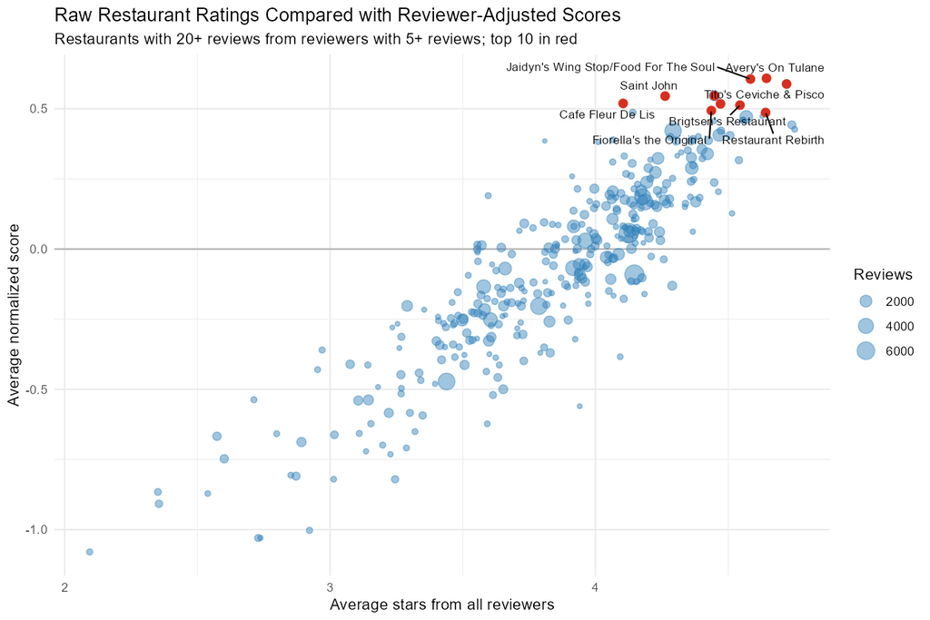

Raw average stars vs. reviewer-adjusted score

Restaurants that drop, such as The Governor and Gallier Restaurant & Oyster Bar, likely get their stars from reviewers who rate most places highly. Restaurants that rise, such as Le Citron Bistro and Flambo Burgers & Bar, are rated above average by tougher reviewers. Some of the movement is also sample size: a restaurant with exactly 20 eligible reviews (Saint John) can swing more than one with 487 (GW Fins).

### Neighborhoods

| Neighborhood | Restaurants | Ranked restaurants | Above reviewers’ norm | In top 10 | Avg stars (all reviewers) | Raw rank | Avg adjusted score | Adjusted rank |
| --- | --- | --- | --- | --- | --- | --- | --- | --- |
| Leonidas | 14 | 9 | 7 | 1 | 4.29 | 1 | 0.24 | 1 |
| Uptown | 10 | 6 | 4 | 1 | 4.04 | 5 | 0.17 | 2 |
| East Riverside | 11 | 9 | 5 | 0 | 4.10 | 4 | 0.14 | 3 |
| Lower Garden District | 31 | 21 | 12 | 1 | 4.12 | 3 | 0.14 | 4 |
| Seventh Ward | 11 | 5 | 4 | 0 | 4.17 | 2 | 0.09 | 5 |
| Mid-City | 21 | 15 | 7 | 1 | 3.95 | 6 | 0.02 | 6 |
| Marigny | 19 | 11 | 6 | 0 | 3.94 | 7 | -0.03 | 7 |
| French Quarter | 150 | 103 | 34 | 2 | 3.85 | 10 | -0.07 | 8 |
| Central Business District | 102 | 62 | 23 | 1 | 3.86 | 9 | -0.07 | 9 |
| Central City | 29 | 16 | 7 | 0 | 3.91 | 8 | -0.08 | 10 |

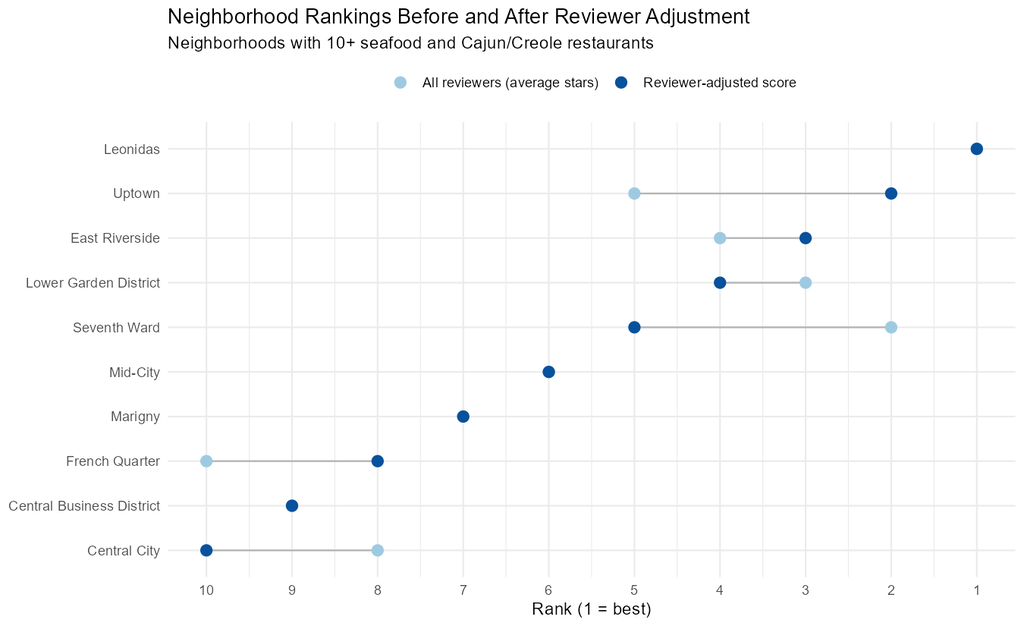

Neighborhood rankings before and after reviewer adjustment

## Limitations

- **The data is old and partial.** Reviews end in January 2022, and the Yelp Open Dataset is a sample of businesses, not all of Yelp. Some restaurants may have closed.
- **Categories are self-reported tags.** Jaidyn’s Wing Stop and Mr John’s Steakhouse are tagged Seafood or Cajun/Creole but are not primarily seafood restaurants.
- **The baseline is limited to this category.** A reviewer’s “usual rating” is only from their seafood and Cajun/Creole reviews. Only 4.5% of reviewers have 5 or more such reviews, so the adjusted score rests on 21.5% of reviews.
- **Small neighborhoods are left out.** 44 of the 54 neighborhoods with restaurants have fewer than 10 and are not ranked.
- **Reviewers are not random.** French Quarter reviewers are likely mostly tourists, while Uptown reviewers may be more local, which can affect both raw and adjusted scores.

## AI Prompts Used

I wrote the code for this project and made the decisions regarding the research question, food categories, geographic areas, methodology, thresholds, visualizations, and final content included in the repository. I used Claude Code primarily as a tool to review my code, identify potential errors, verify that my code was implementing my intended methodology, and help interpret the results and visualizations I produced.

- **Code review and debugging**
  - **Prompt:** “I wrote this R code for my Yelp analysis. Can you review it for syntax errors, logical mistakes, or anything that could cause incorrect results?”
  - **Reprompt:** “Don’t rewrite the analysis or change my methodology. Just check that the code I wrote correctly implements what I am trying to do and point out any problems.”
- **Large Yelp dataset processing**
  - **Prompt:** “I wrote this code to process the large Yelp review JSON file in chunks because loading the entire file into memory is causing problems. Can you check whether my approach is working correctly and whether I am keeping only the data I need?”
  - **Reprompt:** “Keep my overall approach the same. I mainly want to make sure my chunked processing code is correct and isn’t accidentally dropping or changing relevant reviews.”
- **Restaurant/category filtering**
  - **Prompt:** “Can you check the filtering code I wrote and verify that it correctly selects New Orleans businesses belonging to at least one of my chosen categories: Seafood, Cajun/Creole, or Seafood Markets?”
  - **Reprompt:** “I chose these categories myself. I just want you to verify that my code applies the inclusion rule correctly, including restaurants that belong to multiple categories.”
- **Geographic/spatial analysis**
  - **Prompt:** “I wrote this spatial join code to assign restaurants to different New Orleans geographic boundaries. Can you check whether the joins and unmatched restaurant calculations are being performed correctly?”
  - **Reprompt:** “I selected the geographic systems and will decide which one to use. Just verify my code and help me understand what the resulting differences between the geographic systems mean.”
- **Reviewer normalization**
  - **Prompt:** “I wrote this code to adjust restaurant scores based on each reviewer’s normal rating behavior. Can you check whether my reviewer-normalization calculation is implemented correctly?”
  - **Reprompt:** “Don’t replace the normalization method. I chose this approach; I just want you to verify my implementation and help explain what positive and negative adjusted scores mean.”
- **Reviewer threshold and sensitivity analysis**
  - **Prompt:** “I chose a minimum reviewer activity threshold and wrote this code to test how different thresholds affect the results. Can you verify that the thresholds are being applied correctly and help me interpret whether the results are sensitive to this choice?”
  - **Reprompt:** “Focus on what my results show rather than choosing a threshold for me. I want to determine whether my selected threshold is reasonable based on the analysis I performed.”
- **Interpreting charts and results**
  - **Prompt:** “I generated this visualization from my analysis. Can you help me identify the main patterns shown in the chart and explain what they mean without making claims that aren’t supported by the data?”
  - **Reprompt:** “Make the explanation more concise and only discuss conclusions that can actually be supported by the values in my visualization.”
- **Final code and repository check**
  - **Prompt:** “I finished writing the code and analysis for my project. Can you review the project as a final check for coding errors, inconsistencies between my code and written explanations, or anything that might prevent the analysis from reproducing correctly?”
  - **Reprompt:** “Don’t redesign the project or change my analytical decisions. I want a final technical review of the code and results I produced.”